# Data Visualization with ggplot2 (Part 2)

Bourbon0212

2018年7月21日

- [Data Visualization with ggplot2 (Part 1)](https://bourbon0212.github.io/NTU-CS-X/Week2/Data_Visualization_with_ggplot2__Part_1_.html)
- Statistics
  - Stats & Geoms
  - Smooth
  - Quantile
  - Sum
  - Independent Stats
  - Summary
- Coordinates & Facets
  - Zooming In
  - Aspect Ratio
  - Pie Chart
  - Facet
- Themes
  - Rectangles
  - Lines
  - Text
  - Position
  - Reuse Theme
  - `ggtheme`
- Common Pitfalls
  - Dynamite Plots & Alternatives
  - Pie Charts & Alternatives
  - Heat Map & Alternatives
- Case Study - Mosaic Plots
  - Chi-Squared Test & Mosaic PLots
- [Data Visualization with ggplot2 (Part 3)](https://bourbon0212.github.io/NTU-CS-X/Week4/Data_Visualization_with_ggplot2__Part_3_.html)

# **Statistics**

Two categories of **Statistics Layers Functions**:

- Called from within a `geom`. e.g. Bin, Smooth, Quantile, Sum
- Called independently. e.g. Summary, Function, QQ

## Stats & Geoms

As we seen before in **[Histograms](https://bourbon0212.github.io/NTU-CS-X/Week2/Data_Visualization_with_ggplot2__Part_1_.html#4.3.1)**, we’ve already encountered stats functions when we used `geom_histogram()`.  
Recall that under the hood, this function called `stat = 'bin'` to summarize the total count & proportion in each group.  
And we can get those inner data by using `..count..` or `..density..`.  
Similarly, as we used `geom_bar()`, its default stats is set to `'bin'`.

```r
library(ggplot2)
```

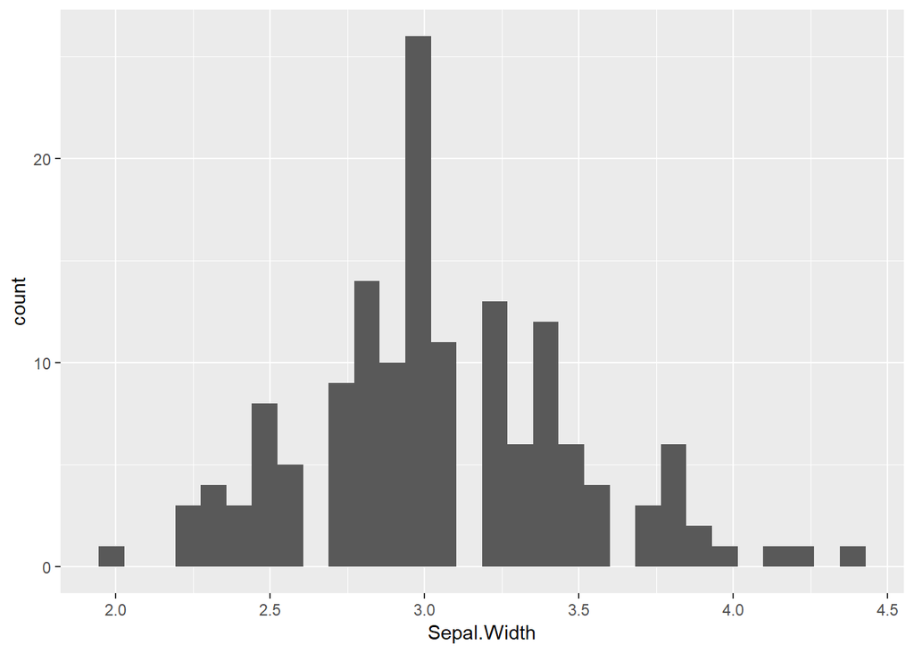

```r
plot <- ggplot(iris, aes(x = Sepal.Width))
plot + geom_histogram()
plot + geom_bar()
plot + stat_bin()
```

[output not shown]

Here are some other examples:

| stat_ | geom_ |
| --- | --- |
| stat_bin() | [geom_bar()](https://bourbon0212.github.io/NTU-CS-X/Week2/Data_Visualization_with_ggplot2__Part_1_.html#4.3.2) |
| stat_bin() | [geom_histogram()](https://bourbon0212.github.io/NTU-CS-X/Week2/Data_Visualization_with_ggplot2__Part_1_.html#4.3.1) |
| stat_bin() | geom_freqpoly() |
| stat_smooth() | geom_smooth() |
| stat_boxplot() | geom_boxplot() |
| stat_bindplot() | geom_dotplot() |
| stat_bin2d() | geom_bin2d() |
| stat_binhex() | geom_hex() |
| stat_contour() | geom_contour() |
| stat_quantile() | geom_quantile() |
| stat_sum() | geom_count() |

## Smooth

- When we use `geom_smooth()`, we call **`stat_smmoth()`** simultaneously.
- `se`: The standard error shown as a gray ribbon behind our smooth, is by default the 95 percent confidence interval.
  - `se = Fales`: To remove this gray ribbon.
- `fullrange`: Whether to show the prediction according your dataset. Error increases the further away from our dataset.
- Default `method = 'auto'`
  - For largest group < 1000: `method = 'loess'`
  - For largest group > 1000: `method = 'gam'`
- `Method = 'loess'`
  - Works like passing as a sliding window along the x axis.
  - Within each window, a weighted **mean** is calculated for the model.
  - `span`: Controls alpha (the degree of smoothing or windows size), smaller spans are more noisy.

#### **Example1 : mtcars**

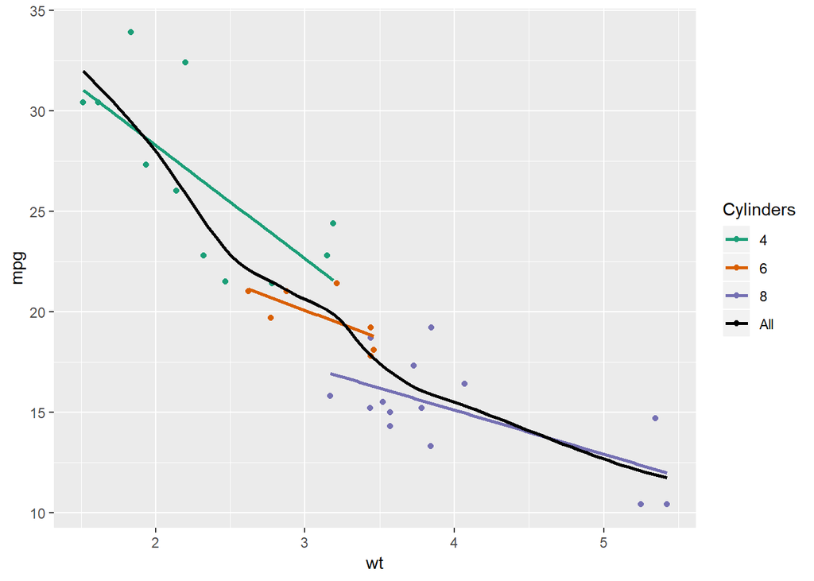

```r
# Customize color
library(RColorBrewer)
myColors <- c(brewer.pal(3, "Dark2"), "black")

ggplot(mtcars, aes(x = wt, y = mpg, col = factor(cyl))) +
  geom_point() +
  stat_smooth(method = "lm", se = FALSE) +
  stat_smooth(method = "loess",
              aes(group = 1, col="All"),
              se = FALSE, span = 0.7) +
  # Add correct arguments to scale_color_manual
  scale_color_manual('Cylinders', values = myColors)
```

#### **Example2: Vocab**

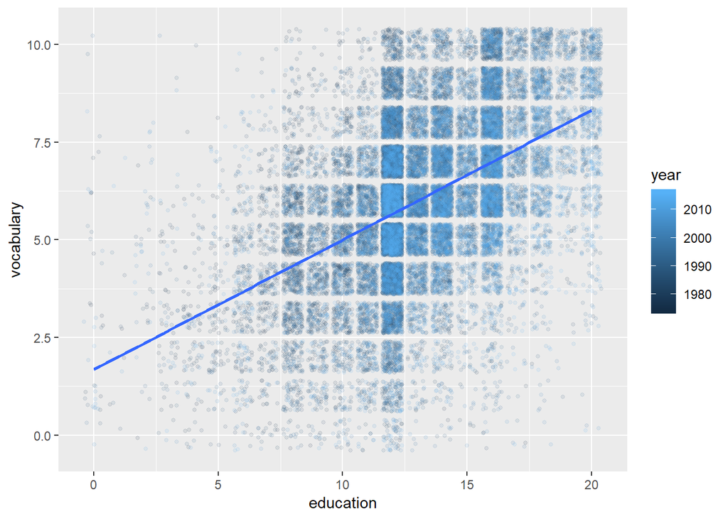

```r
library(car)
ggplot(Vocab, aes(x = education, y = vocabulary, col = year)) +
  geom_jitter(alpha = 0.1, size = 1) +
  stat_smooth(method = 'lm', se = F)
```

When mapping onto color you can sometimes treat a continuous scale, like `year`, as an ordinal variable, but only if it is a regular series.  
The better alternative is to leave it as a continuous variable and use the `group` aesthetic as a factor to make sure your plot is drawn correctly.

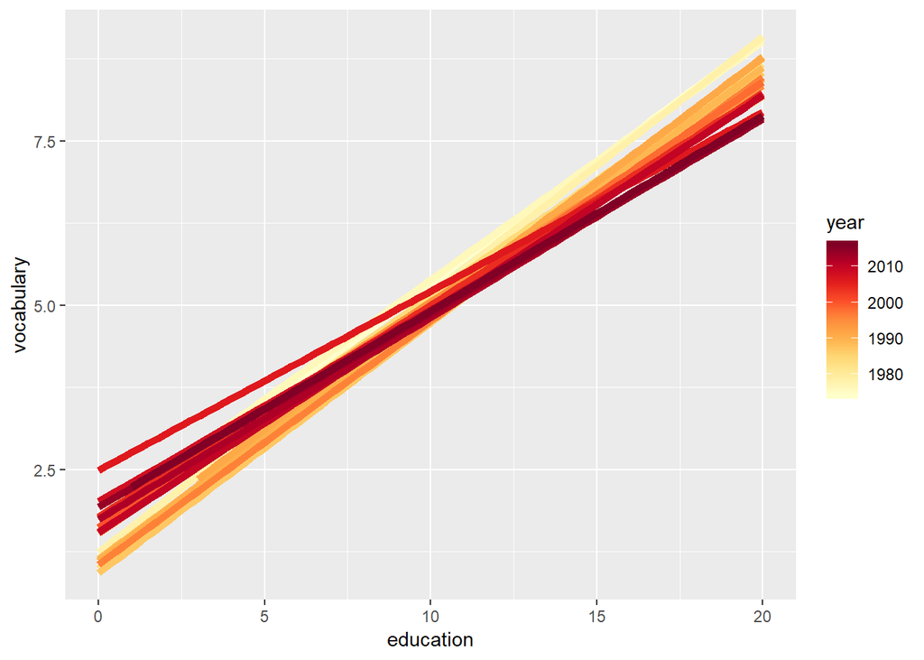

```r
# Specify the invisible group aesthetic so that our linear models are still calculated appropriately.
ggplot(Vocab, aes(x = education, y = vocabulary, col = year, group = factor(year))) +
  stat_smooth(method = "lm", se = FALSE, alpha = 0.6, size = 2) +
  scale_color_gradientn(colors = brewer.pal(9, "YlOrRd"))
```

We used the `Vocab` dataset and applied linear models describing `vocabulary` by `education` for different years.

## Quantile

- **`stat_quantile()`** calculates quantiles according ypur data and draw them in linear models.
- By default it calculates the 1st, 2nd (i.e. **median**), and 3rd quartiles.

#### **Example: Vocab**

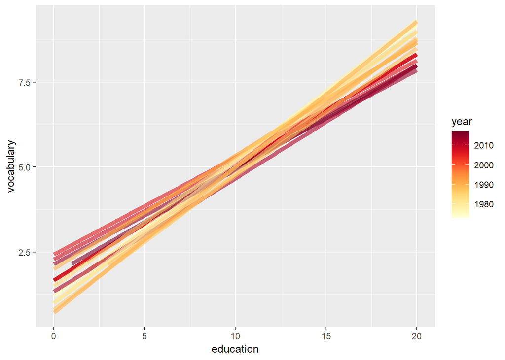

```r
ggplot(Vocab, aes(x = education, y = vocabulary, col = year, group = factor(year))) +
  # Set the quantiles argument to 0.5 so that only the median is shown.
  stat_quantile(alpha = 0.6, size = 2, quantiles = 0.5) +
  scale_color_gradientn(colors = brewer.pal(9,"YlOrRd"))
```

## Sum

- **`stat_sum()`** calculates the total number of overlapping observations and is another good alternative to overplotting.
- This maps the overall `count` of each dot onto `size`.

#### **Example: Vocab**

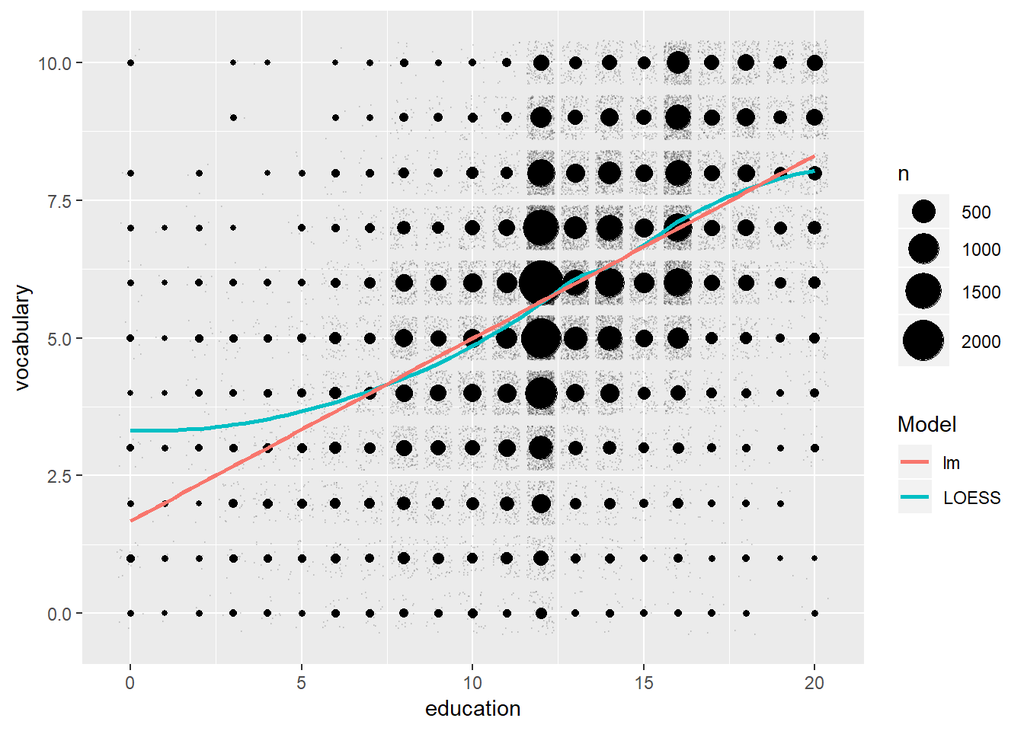

```r
ggplot(Vocab, aes(x = education, y = vocabulary)) +
  geom_jitter(size = 0.1, alpha = 0.1) +
  stat_sum() + # sum statistic
  scale_size(range = c(1, 10)) +  # set size scale
  stat_smooth(method = "loess", aes(col = "LOESS"), se = F) +
  stat_smooth(method = "lm", aes(col = "lm"), se = F) +
  scale_color_discrete("Model")
```

## Independent Stats

As mentioned before, there are two categorical function in Statistics.  
It’s time to look at the second group of stats function: **Independent Stats**.

| stat_ | Discription |
| --- | --- |
| stat_summary() | Summarise y values at distinct x values. |
| stat_function() | Compute y values from a function of x values. |
| stat_qq() | Perform calculations for a quantile-quantile plot. |

## Summary

Here we’ll look at **`stat_summary()`** in action.

- Default `geom = 'pointrange'`.
- `fun.data = mean_sdl, fun.args = list(mult = 1)`: Calculate mean & sd.
- `fun.data = mean_cl_normal`: Calculate mean and 95% confidence interval.

#### **Example: mtcars**

Before we start, there are some preparation need to be done.

```r
# Require 'Hsimc' package here.
library(Hmisc)
# Convert cyl and am to factors
mtcars$cyl <- as.factor(mtcars$cyl)
mtcars$am <- as.factor(mtcars$am)

# Define positions
posn.d <- position_dodge(width = 0.1)
posn.jd <- position_jitterdodge(jitter.width = 0.1, dodge.width = 0.2)
posn.j <- position_jitter(width = 0.2)

# Base layers
wt.cyl.am <- ggplot(mtcars, aes(x = cyl, y = wt, col = am, fill = am, group = am))
```

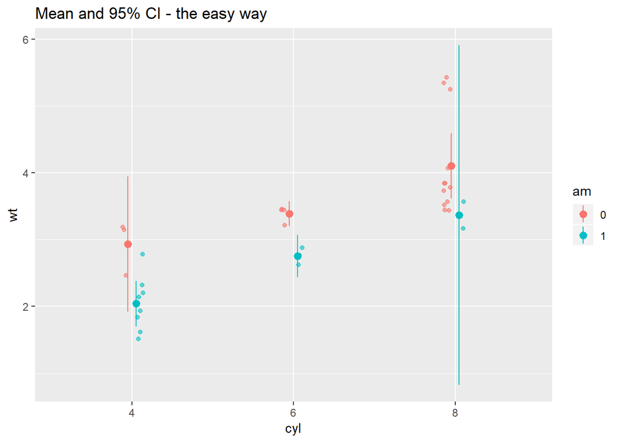

```r
# Mean and 95% CI - the easy way
wt.cyl.am +
  geom_point(position = posn.jd, alpha = 0.6) +
  # 95% CI: 'fun.data = mean_cl_normal'
  # Default geom = 'pointrange'
  stat_summary(fun.data = mean_cl_normal, position = posn.d) +
  ggtitle('Mean and 95% CI - the easy way')
```

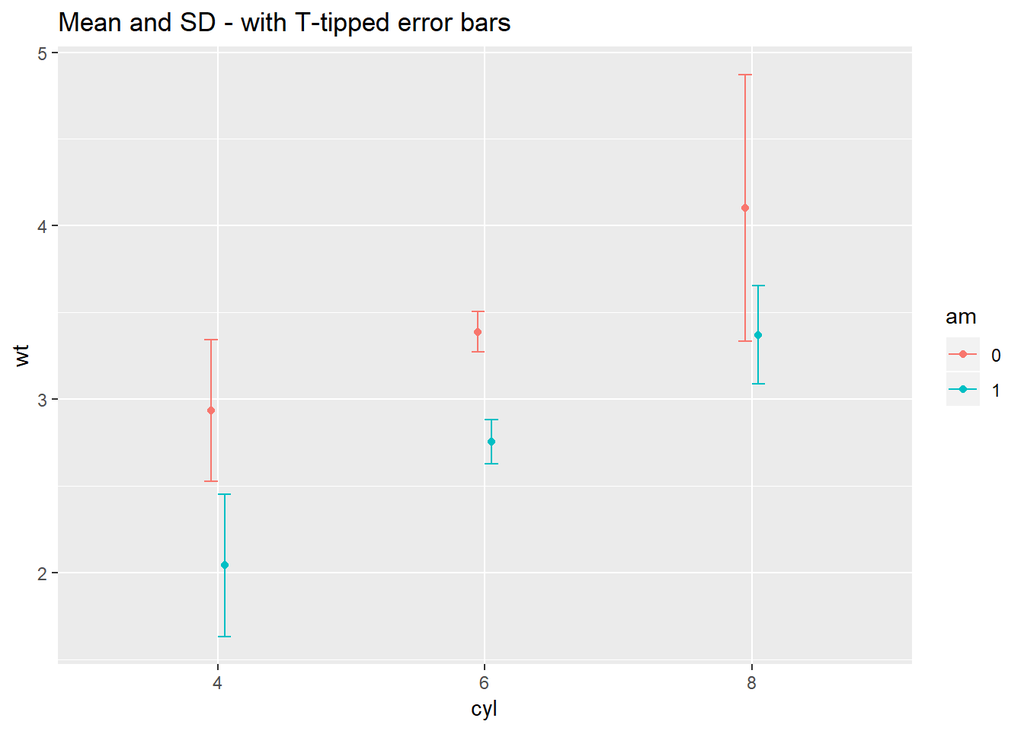

```r
# Mean and SD - with T-tipped error bars
wt.cyl.am +
  # Mean: 'fun.y = mean' -> Uses the y aesthetic
  stat_summary(geom = 'point', fun.y = mean,
               position = posn.d) +
  # sd: 'fun.data = mean_sdl, fun.args = list(mult = 1)'
  # fun.args = list(mult = 1) to have a errorbar that spans over one standard deviation in both directions.
  stat_summary(geom = 'errorbar', fun.data = mean_sdl,
               position = posn.d, fun.args = list(mult = 1), width = 0.1) +
  ggtitle('Mean and SD - with T-tipped error bars')
```

Notice here, `quantile()` returns a vector of 5 units: 0%, 25%, 50%, 75%, 100%.  
So 1st quartile equals `quantile(x)[2]`, 3rd quartile equals `quantile(x)[4]`.

```r
# Function to save range for use in ggplot
gg_range <- function(x) {
  data.frame(ymin = min(x), # Min
             ymax = max(x)) # Max
}

# Function to get quantiles
med_IQR <- function(x) {
  data.frame(y = median(x), # Median
             ymin = quantile(x)[2], # 1st quartile
             ymax = quantile(x)[4])  # 3rd quartile
}
```

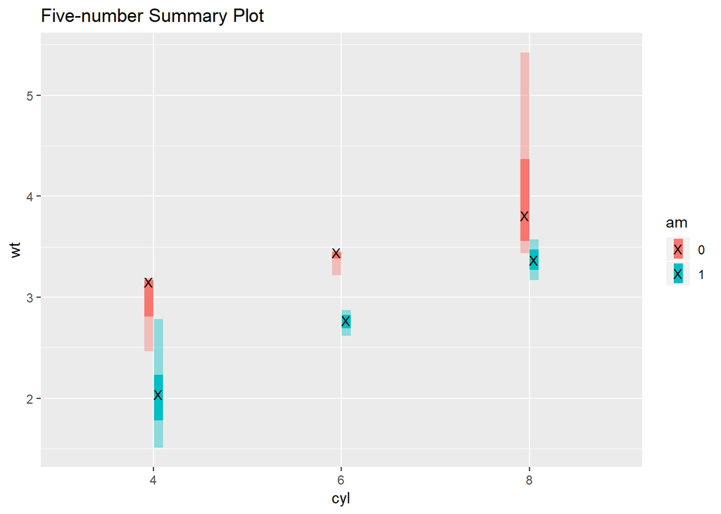

```r
# Five-number summary(the minimum, 1st quartile, median, 3rd quartile, and the maximum) plot
wt.cyl.am +
  # 1st quartile, 3rd quartile
  stat_summary(geom = 'linerange', fun.data = med_IQR,
               position = posn.d, size = 3) +
  # minimum, maximum
  stat_summary(geom = 'linerange', fun.data = gg_range,
               position = posn.d, size = 3,
               alpha = 0.4) +
  # median
  stat_summary(geom = 'point', fun.y = median,
               position = posn.d, size = 3,
               col = 'black', shape = 'X') +
  ggtitle('Five-number Summary Plot')
```

# **Coordinates & Facets**

- Coordinates Layer
  - `coord_` function e.g. `coord_cartesian()`
- Facets Layer
  - Separate plots from one plot according to row or column.
  - `facet_grid(row ~column)`

## Zooming In

- `scale_x_continuous(limits = c(*,*))`
  - Filtered original dataset caused missing data.
  - `geom_smooth()` might be different.
- `xlim(c(*,*))`
  - Similar to the function above, but in a fast & dirty way.
- **`coord_cartesin(xlim = c(*,*))`**
  - **Preferred way when zooming in**.
  - Truly do simply zoom in on the plot without losing anything.

#### **Example: mtcars**

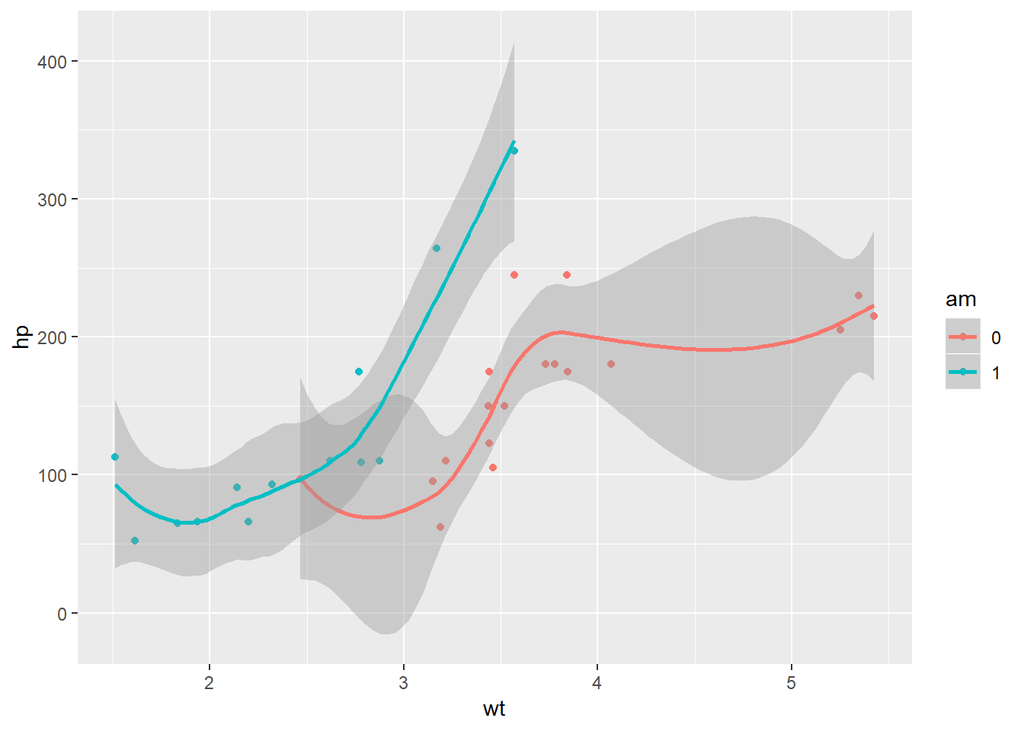

```r
plot2 <- ggplot(mtcars, aes(x = wt, y = hp, col = am)) + geom_point() + geom_smooth()
# Original plot
plot2
```

When using `scale_x_continuous(limits = c(*,*))`, you’ll get lots of warnings(do not show here.) and a weird graph.

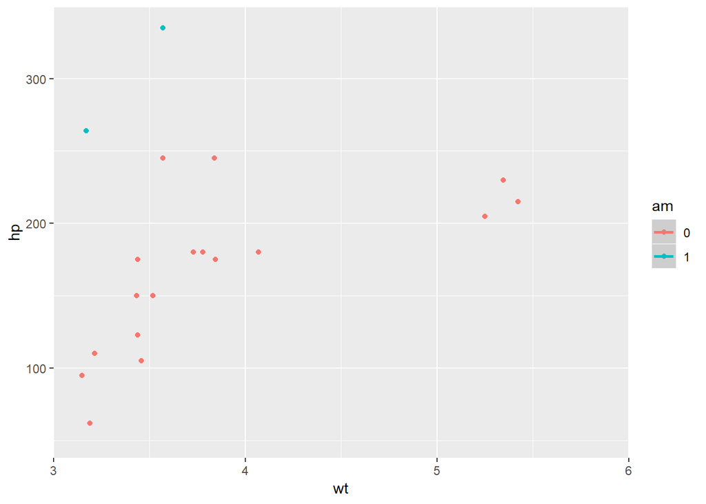

```r
# Zoom in using scale function.
plot2 +
    scale_x_continuous(limits = c(3, 6), expand = c(0, 0))
```

`coord_cartesin(xlim = c(*,*))` is just what we want.

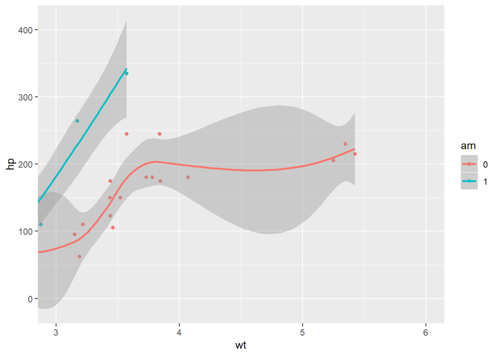

```r
# Zoom in using coord function.
plot2 +
  coord_cartesian(xlim = c(3, 6))
```

## Aespect Ratio

Set the aspect ratio of a plot with **`coord_fixed()`** or **`coord_equal()`**. Both use `ratio = 1` as a default.

- `ratio = x/y`
- ratio is not always = 1, there are some exceptions.

#### **Example: iris**

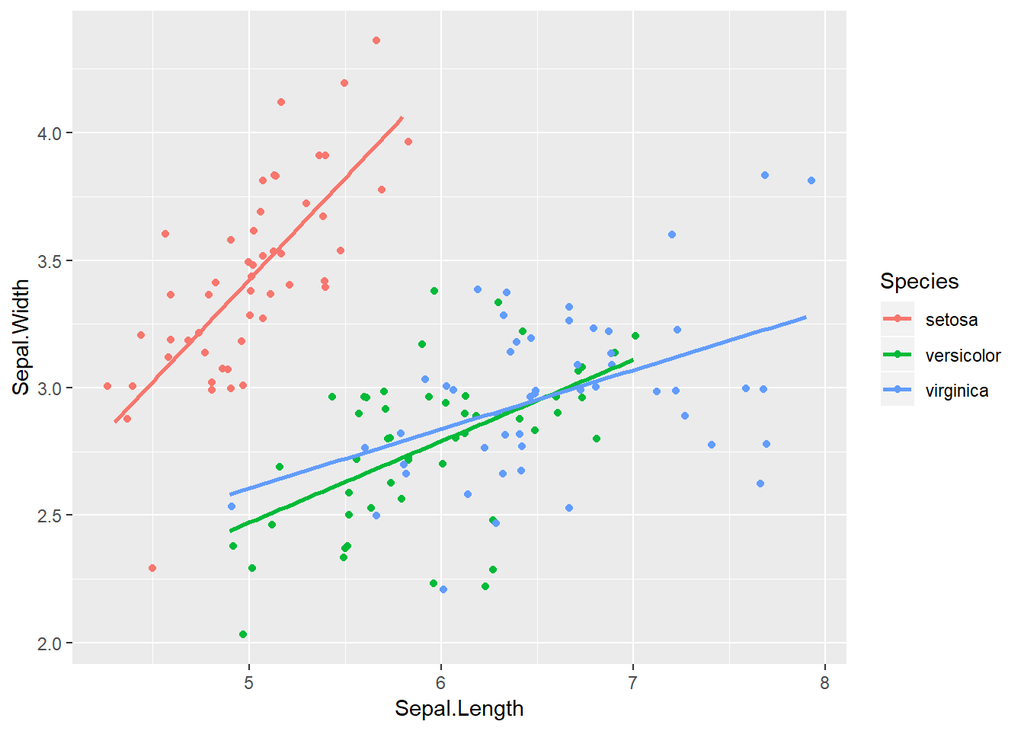

```r
base.plot <- ggplot(iris, aes(x = Sepal.Length, y = Sepal.Width, col = Species)) +
               geom_jitter() +
               geom_smooth(method = "lm", se = FALSE)

# Plot base.plot: default aspect ratio
base.plot
```

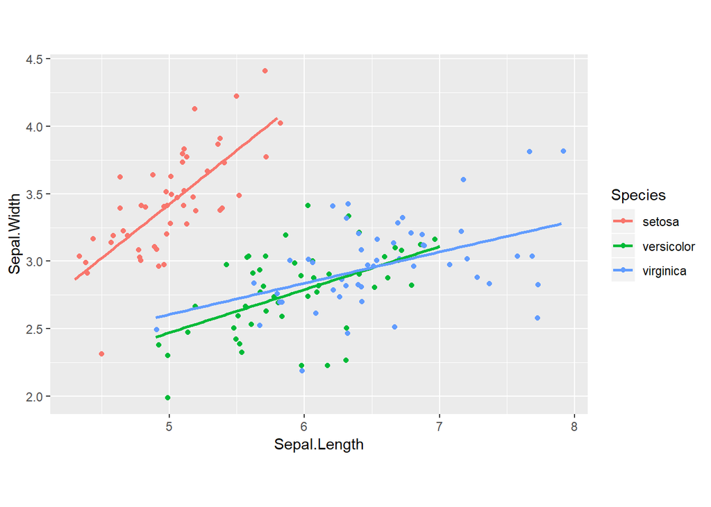

```r
# Fix aspect ratio (1:1) of base.plot
base.plot +
  coord_equal()
```

## Pie Chart

Use **`coord_polar(theta = '*axis')`** to transform a bar char onto a **polar coordinate system**.

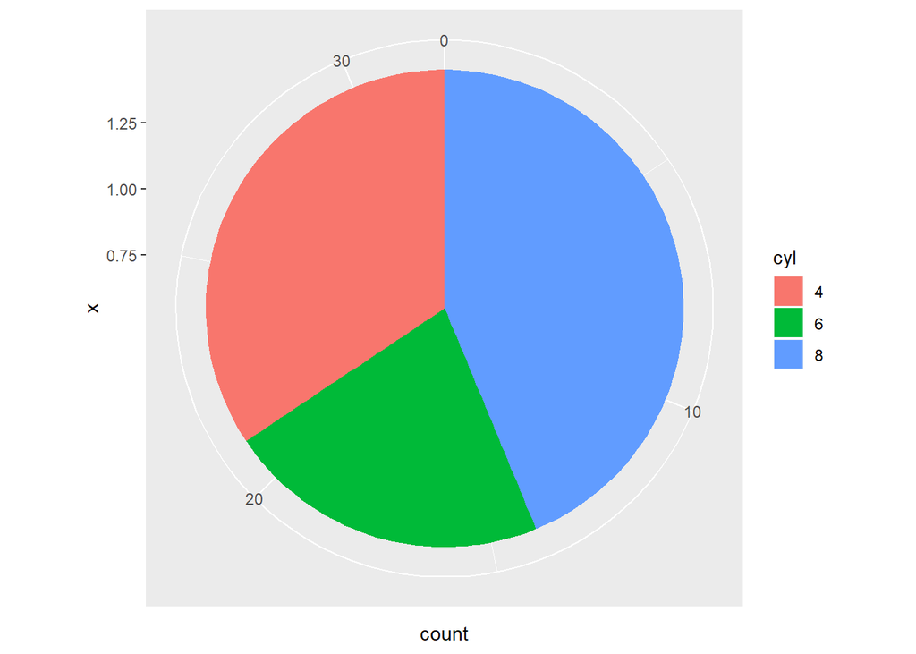

```r
# Create an ordinary bar chart and convert it into pie chart.
wide.bar <- ggplot(mtcars, aes(x = 1, fill = cyl)) +
              geom_bar()
wide.bar +
  coord_polar(theta = 'y')
```

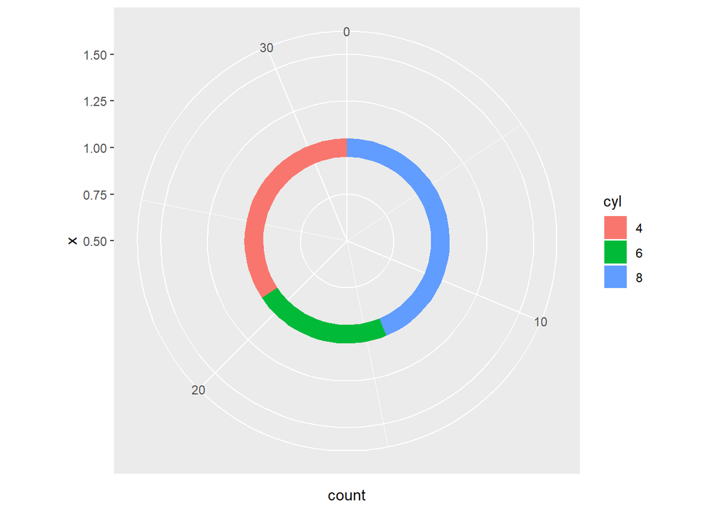

```r
# Set limits on x_scale and convert it into a 'ring' type pie chart.
thin.bar <- ggplot(mtcars, aes(x = 1, fill = cyl)) +
              geom_bar(width = 0.1) +
              scale_x_continuous(limits = c(0.5, 1.5))
thin.bar +
  coord_polar(theta = 'y')
```

## Facet

The most straightforward way of using facets is **`facet_grid()`**.  
Here we just need to specify the categorical variable to use on rows and columns using standard R formula notation **`(rows ~ columns)`**. Remember, when faceting in only one direction us `.` to specify nothing for the unused direction.

#### **Example - Multivariables: mtcars**

Here we’ll present a plot with 6 variables in mtcars

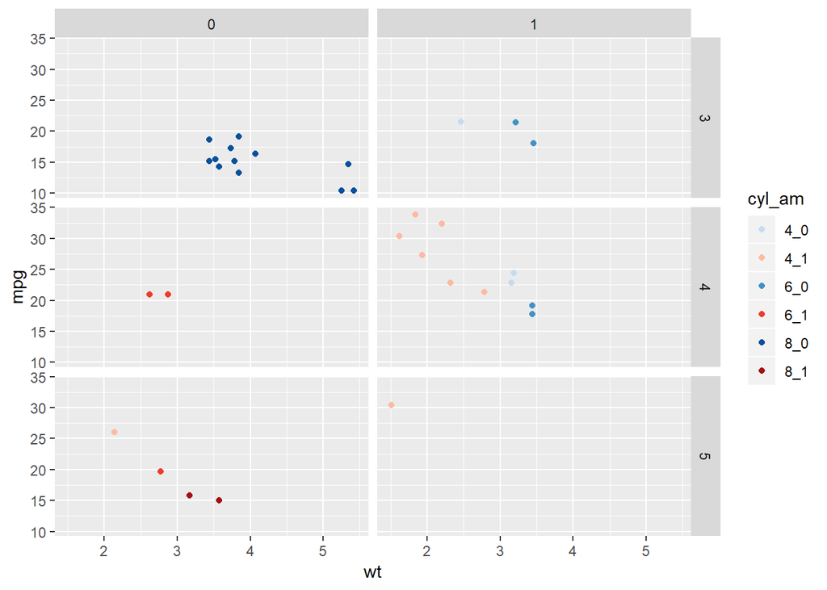

```r
# Create cyl_am
mtcars$cyl_am <- paste(mtcars$cyl, mtcars$am, sep = "_")
# Customize color
myCol <- rbind(brewer.pal(9, "Blues")[c(3,6,8)],
               brewer.pal(9, "Reds")[c(3,6,8)])
# Plot with multi variables.
ggplot(mtcars, aes(x = wt, y = mpg, col = cyl_am)) +
  geom_point() +
  scale_color_manual(values = myCol) +
  facet_grid(gear ~ vs)
```

#### **Example - Dropping Levels: msleep**

The variables of interest here are `name`, which contains the full popular name of each animal, and `vore`, the eating behavior. We are going to facet the plot with `vore`. Each animal can only be classified under one eating habit, so if we facet according to `vore`, we don’t need to repeat the full list in each sub-plot.  
Use `scale = "free_y"` and `space = "free_y"` to leave out rows for which there is no data.

```r
library(tidyr)
library(dplyr)
# Take a look at msleep
head(msleep, 3)
```

```
## # A tibble: 3 x 11
##   name    genus vore  order conservation sleep_total sleep_rem sleep_cycle
##   <chr>   <chr> <chr> <chr> <chr>              <dbl>     <dbl>       <dbl>
## 1 Cheetah Acin~ carni Carn~ lc                  12.1      NA            NA
## 2 Owl mo~ Aotus omni  Prim~ <NA>                17         1.8          NA
## 3 Mounta~ Aplo~ herbi Rode~ nt                  14.4       2.4          NA
## # ... with 3 more variables: awake <dbl>, brainwt <dbl>, bodywt <dbl>
```

```r
# Tidy data for plot
colnames(msleep)[6:7] <- c('total', 'rem')
mamsleep <- msleep %>%
              gather(sleep, time, total:rem) %>%
              select(vore, name, sleep, time) %>%
              filter(!is.na(vore))
# After tidy up
head(mamsleep, 3)
```

```
## # A tibble: 3 x 4
##   vore  name            sleep  time
##   <chr> <chr>           <chr> <dbl>
## 1 carni Cheetah         total  12.1
## 2 omni  Owl monkey      total  17
## 3 herbi Mountain beaver total  14.4
```

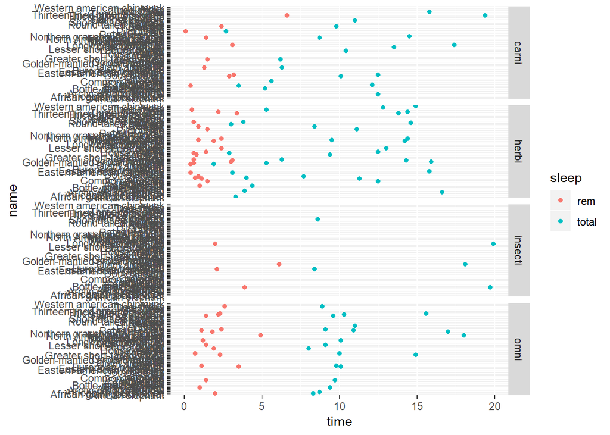

```r
plot3 <- ggplot(mamsleep, aes(x = time, y = name, col = sleep)) + geom_point()
# Before dropping levels
plot3 + facet_grid(vore ~ .)
```

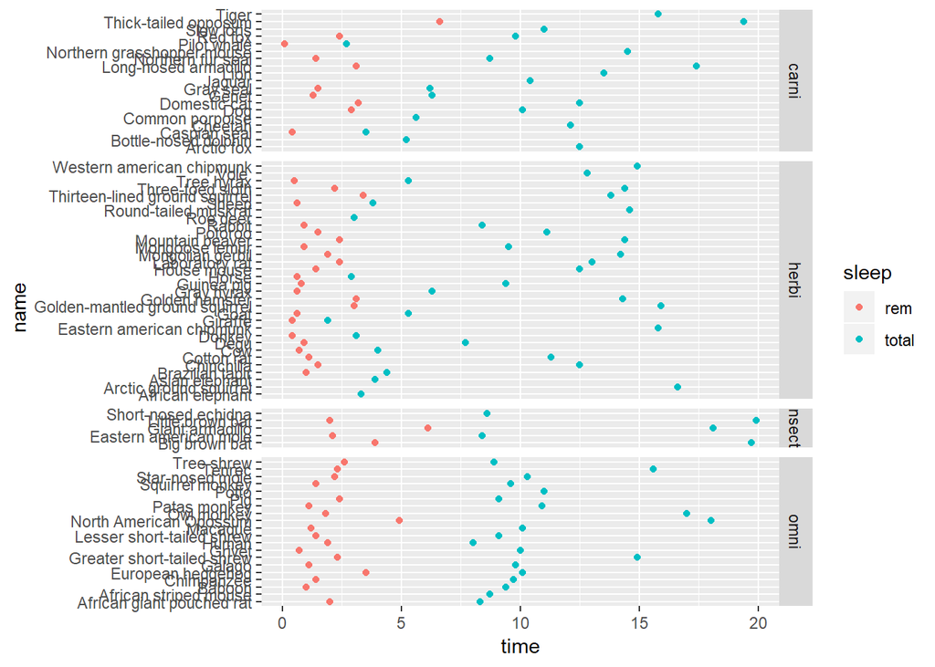

```r
# After dropping levels(free up rows)
plot3 + facet_grid(vore ~ ., scale= 'free_y', space = 'free_y')
```

# **Themes**

- All non-data ink. e.g. color, angle, size, position…etc.
- Visual elements not part of data.
- Three types
  - text: `element_text()`
  - line: `element_line()`
  - rectangle: `element_rect()`
- Put these attributes in `theme()` layer.
- `element_blank()` for not displaying the stuff.
- Inheritance: Elements inherit from each other in a hierarchy.

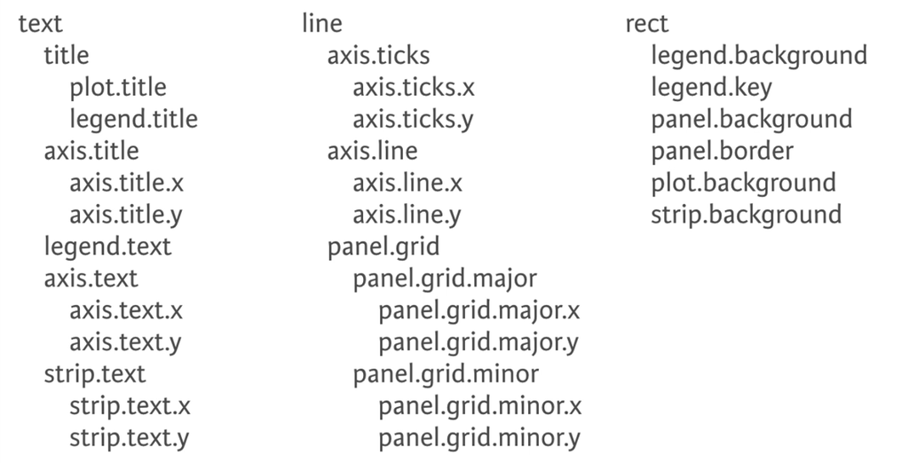

And here is our base plot, the most familiar dataset - mtcars.

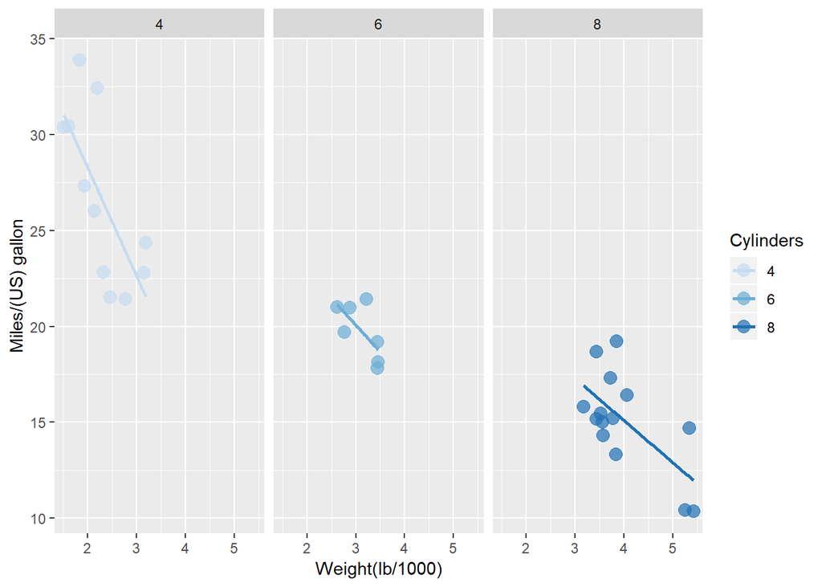

```r
library(RColorBrewer)
plot4 <- ggplot(mtcars, aes(x = wt, y = mpg, col = factor(cyl))) +
  stat_smooth(method = 'lm', se = F) +
  scale_color_manual('Cylinders', values = c('#C6DBEF','#6BAED6','#2171B5')) +
  geom_jitter(size = 3.5, alpha = 0.7) +
  scale_x_continuous('Weight(lb/1000)') +
  scale_y_continuous('Miles/(US) gallon') +
  facet_grid(.~cyl)
plot4
```

## Rectangles

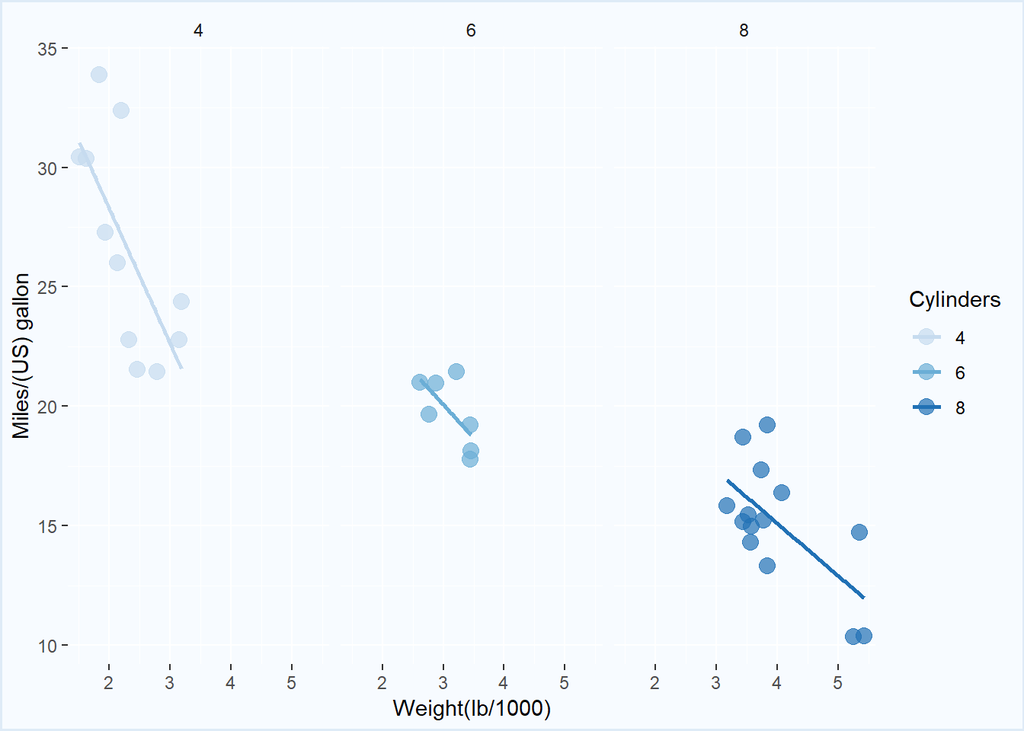

```r
plot5 <- plot4 +
  # Theme to remove all rectangles
  theme(rect = element_blank()) +
  # Combine custom themes
  theme(plot.background = element_rect(fill = '#F7FBFf', color = '#DEEBF7', size = 1))
plot5
```

## Lines

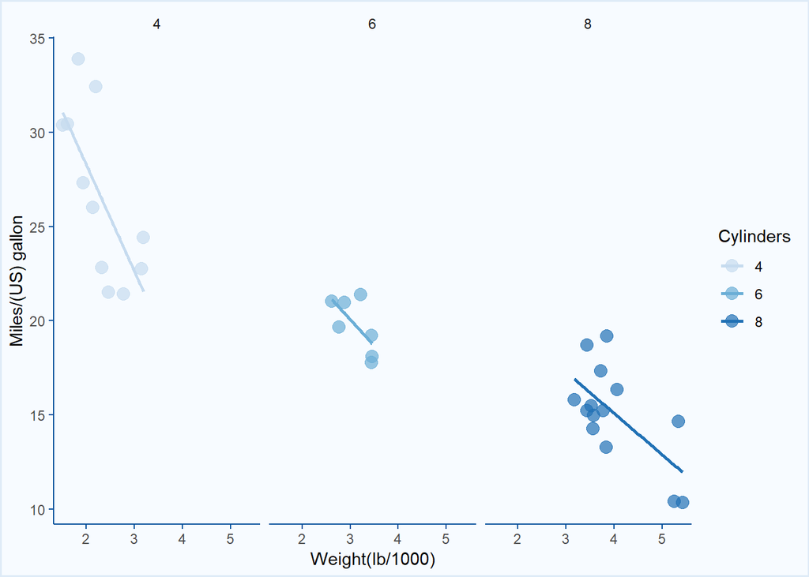

```r
plot6 <- plot5 +
        # Remove grid
  theme(panel.grid = element_blank(),
        # Set color of axis.line
        axis.line = element_line(color = '#08519C'),
        #Set color of axis.ticks
        axis.ticks = element_line(color = '#08519C'))
plot6
```

## Text

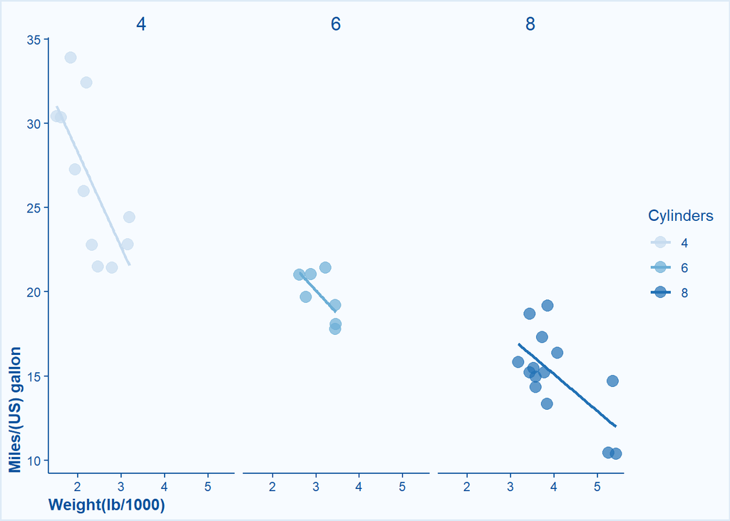

```r
plot7 <- plot6 +
  theme(strip.text = element_text(size = 13, color = '#08519C'),
        # 'hjust = 0' to put the text in the bottom left corner
        axis.title = element_text(color = '#08519C', hjust = 0, face = 'bold'),
        axis.text = element_text(color = '#08519C'),
        legend.text = element_text(color = '#08519C'),
        legend.title = element_text(color = '#08519C'))
plot7
```

## Position

We can only change the direction & the position of the legend.

- `legend.position` for position.
  - Move by location: `legend.position = c(0.85,0.85)`
  - Move by name: `legend.position = 'bottom'`
- `legend.direction` for direction.

As for the elements of the legend, we need to change it in **`geom` layer using `scale` or `aes`** becasue they are data ink.

We need `library(grid)` to pass a `unit` object in order to adjust position.

- `plot.margin` for adjusting plot margin: `unit(c(top,right,bottom,left), "cm")`
- `panel.spacing` for space between facets.

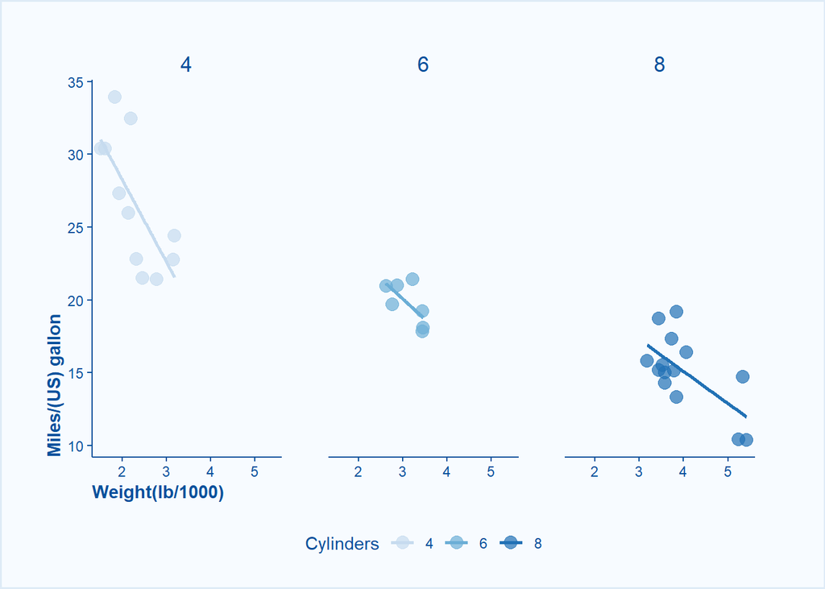

```r
library(grid)
plot8 <- plot7 +
  # Change legend location & direction
  theme(legend.position = 'bottom', legend.direction= 'horizontal') +
  # Adjust the plot margin
  theme(plot.margin = unit(c(1,1.5,0.5,1), 'cm')) +
  # Increase spacing between facets
  theme(panel.spacing.x = unit(1, 'cm'))
plot8
```

## Reuse Theme

- Assign `theme()` layers to a variable, then you can reuse it without copying many lines of codes.
- `theme_update()`: When you call it and assign it to an object, that object stores the **current** default theme, and the arguments **update** the default theme.
- `theme_set()`: Apply theme with `theme_set()`.

```r
theme_blue <-
    theme(rect = element_blank(),
          plot.background = element_rect(fill = '#F7FBFf', color = '#DEEBF7', size = 1),
          panel.grid = element_blank(),
          axis.line = element_line(color = '#08519C'),
          axis.ticks = element_line(color = '#08519C'),
          strip.text = element_text(size = 13, color = '#08519C'),
          axis.title = element_text(color = '#08519C', hjust = 0, face = 'bold'),
          axis.text = element_text(color = '#08519C'),
          legend.text = element_text(color = '#08519C'),
          legend.title = element_text(color = '#08519C'),
          legend.position = 'bottom',
          legend.direction= 'horizontal',
          plot.margin = unit(c(1,1.5,0.5,1), 'cm'),
          panel.spacing.x = unit(1, 'cm'))
```

Apply the theme by `+`.

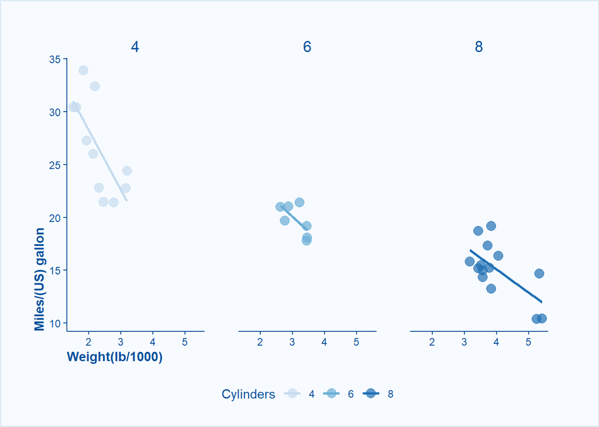

```r
plot4 + theme_blue
```

Update the default theme using `theme_update()`, and store the **current** theme to `original`.

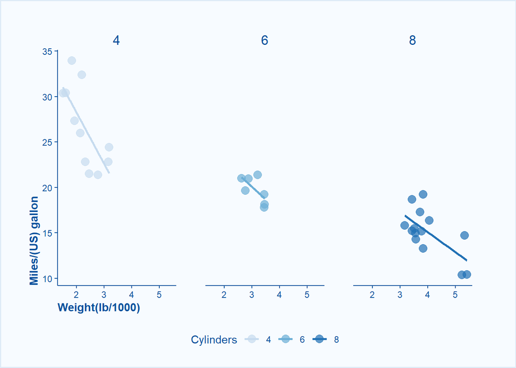

```r
original <- theme_update(rect = element_blank(),
          plot.background = element_rect(fill = '#F7FBFf', color = '#DEEBF7', size = 1),
          panel.grid = element_blank(),
          axis.line = element_line(color = '#08519C'),
          axis.ticks = element_line(color = '#08519C'),
          strip.text = element_text(size = 13, color = '#08519C'),
          axis.title = element_text(color = '#08519C', hjust = 0, face = 'bold'),
          axis.text = element_text(color = '#08519C'),
          legend.text = element_text(color = '#08519C'),
          legend.title = element_text(color = '#08519C'),
          legend.position = 'bottom',
          legend.direction= 'horizontal',
          plot.margin = unit(c(1,1.5,0.5,1), 'cm'),
          panel.spacing.x = unit(1, 'cm'))
plot4
```

Restore back `original` using `theme_set()`.

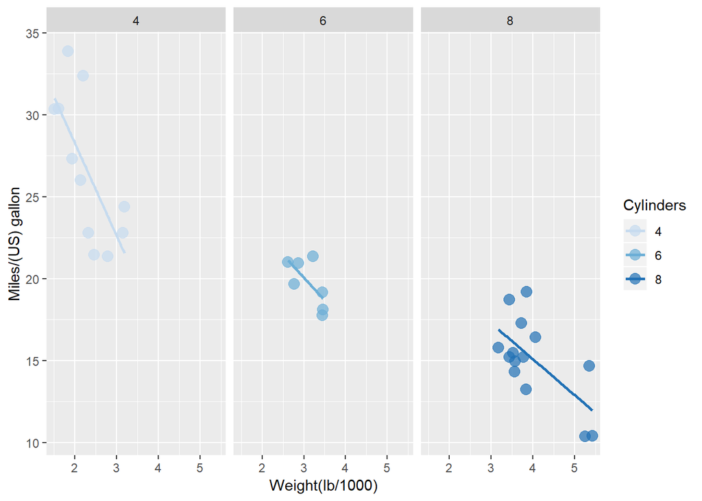

```r
theme_set(original)
plot4
```

## `ggthemes`

There is a package called `ggtheme` which includes many theme set you can choose from, and here are some examples.  
You can combine with `theme_update()` and `theme_set` for default setting.

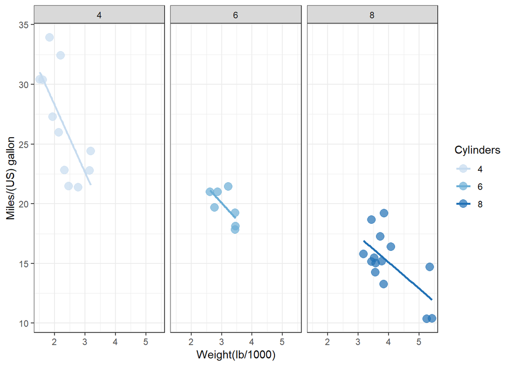

```r
library(ggthemes)
plot4 + theme_bw()
```

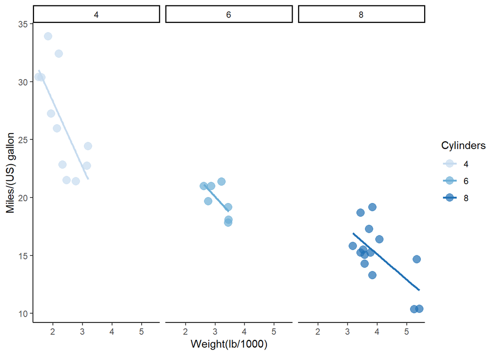

```r
plot4 + theme_classic()
```

# **Common Pitfalls**

So far, you’ve learned how to use `ggplot2`, it’s time to have a deeper look of figuring out **what is the best way to graphically represent our data**.

## Dynamite Plots & Alternatives

As mentioned before, there are two kinds of [bar plots](https://bourbon0212.github.io/NTU-CS-X/Week2/Data_Visualization_with_ggplot2__Part_1_.html#4.3.2):

> Absolute Counts(`stat = 'bin'`)  
> Distribution(`stat = 'identity'`) which is same as `geom_col()` which takes two variables.

The second one is incredibly common and **equally terrible**.  
Let’s turn to `mamsleep` for example.

#### **Example1: Mamsleep**

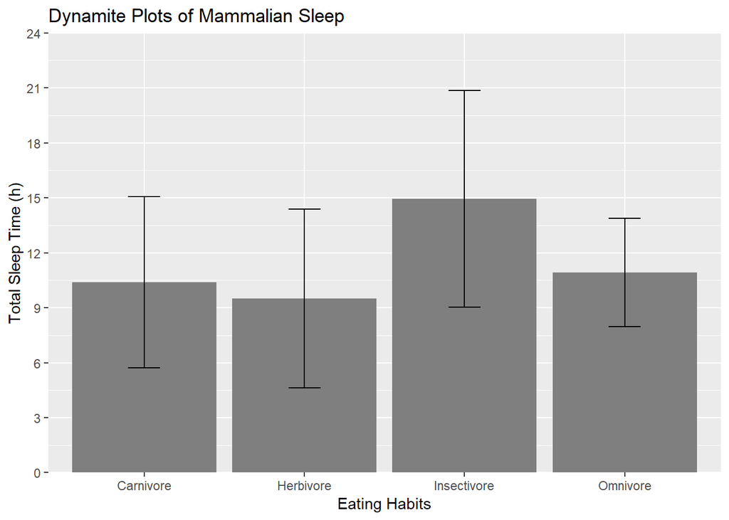

```r
sleep <- spread(mamsleep, sleep, time)
plot9 <- ggplot(sleep, aes(x = vore, y = total)) +
  scale_y_continuous("Total Sleep Time (h)",
                     limits = c(0, 24),
                     breaks = seq(0, 24, 3),
                     expand = c(0, 0)) +
  scale_x_discrete('Eating Habits', labels = c('Carnivore', 'Herbivore', 'Insectivore', 'Omnivore'))

plot9 +
  stat_summary(fun.y = mean, geom = 'bar', fill = 'grey50') +
  stat_summary(fun.data = mean_sdl, fun.args = list(mult = 1), geom = 'errorbar', width = 0.2) +
  ggtitle('Dynamite Plots of Mammalian Sleep')
```

- First, we spread the `mamsleep` data for plotting and assign it to a variable called `sleep`.
- `ggplot(sleep, aes(x = vore, y = total))` make the base of this plot.
  - `vore` is a discrete variable on x-axis which means the eating habbit.
  - `total` is a continuous variable on y-axis which means how much sleep the animal have.
- `scale_y_continuous()`: Rename the y-axis title and set its limits, breaks ,expand.
- `scale_x_discrete()`: Rename the x-axis title and variables’ names.
- Reference: [Scale Function](https://bourbon0212.github.io/NTU-CS-X/Week2/Data_Visualization_with_ggplot2__Part_1_.html#3.3)
- The first `stat_summary()` use `fun.y = mean` to calculate their means.
- The second `stat_summary()` use `fun.data = mean_sdl, fun.args = list(mult = 1)` to calculates their standard deviations.

However, there are some subtle problems in this graph:

- We have no idea how many observations we have in each category.
- This plot is subtly suggesting that our data is normally distributed by using the mean and the standard deviation but it may be not.
- The real data is hidden from us.
- The bars give the impression of having data where there is no data: No mammals which sleep zero hours a day!

**Bar plots should be avoided in this plot.** Let’s change it `geom_point()` for more meaningful plot.

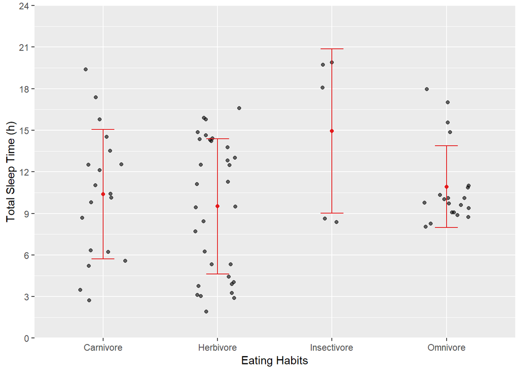

```r
plot9 +
  geom_point(alpha = 0.6, position = position_jitter(width = 0.2)) +
  stat_summary(fun.y = mean, geom = 'point', col = "#E41A1C") +
  stat_summary(fun.data = mean_sdl, fun.args = list(mult = 1), geom = 'errorbar', width = 0.2, col = "#E41A1C")
```

- By using `geom_point()` we can now see the strange patterns in this dataset.
  - We don’t have that much data about insectivores, and wecan say it’s **bimodal**(雙峰) reluctantly.
  - It looks like omnivores are **positive skewed**(右曳).
- Error bars with points are a much cleaner representation of the data.
- It’s much better that we plot `sleep` this way ,and bars are simply not necessary!